# Percom 2023 Demo Paper

paper

conference

demo

code

Author

Malith Gallage, Rafaela Scaciota, Sumudu Samarakoon, and Mehdi Bennis.

## Title

Codesign of Edge Intelligence and Automated Guided Vehicle Control

## System Model

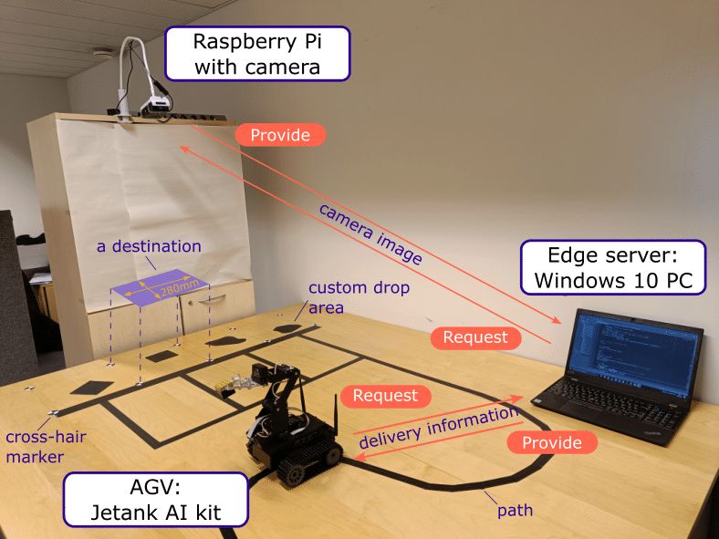

The robotic platform highlighting the components and wireless connectivity.

## Abstract

This work presents a harmonic design of autonomous guided vehicle (AGV) control, edge intelligence, and human input to enable autonomous transportation in industrial environments. The AGV has the capability to navigate between a source and destinations and pick/place objects. The human input implicitly provides preferences of the destination and exact drop point, which are derived from an artificial intelligence (AI) module at the network edge and shared with the AGV over a wireless network. The demonstration indicates that the proposed integrated design of hardware, software, and AI design achieve a technology readiness level (TRL) of range 4-5.

## Index Terms

Edge AI, Image Processing, Autonomous Navigation.

## Acknowledgements

The authors would like to acknowledge the support and contributions of Abdulmomen Ghalka, Dinesh Manimel Wadu, Mithila Amarasena, and Suranga Prasad for developing the image processing solutions.

This work was supported by the projects EU-ICT IntellIoT (grant agreement No. 957218) and Infotech-R2D2.

### Afiliation

Centre for Wireless Communication, University of Oulu, Finland